# Challenge: Classifying breast cancer tumours using Machine Learning

**Shannon Houtermans**

# Table of Contents

```python
import numpy as np
import pandas as pd
import matplotlib.pyplot as plt
import seaborn as sns
import missingno as msno
%matplotlib inline


df = pd.read_csv('E:\Gebruikers\\Shannon\\Downloads\\breast-cancer.csv', sep = ',')
#df = pd.read_csv('C:\\Users\\shann\\Downloads\\breast-cancer.csv', sep = ',')
```

# Project Proposal

## Introduction

In this challenge, I want to research the possibility of classifying tumours found in patients diagnosed with breast cancer. Specifically, I want to find out whether a machine learning algorithm can accurately predict whether a tumour is malignant (cancerous) or benign(non-cancerous), using the properties of tumours from the *Breast Cancer Dataset (https://www.kaggle.com/datasets/yasserh/breast-cancer-dataset)* from Kaggle.

For this, I will try to apply the knowledge that I have gained at the beginning of this semester and create a cohesive document in which I will demonstrate what I'm going to research, what steps I will be taking to perform the research, and what the results of the research will be.

## Domain Understanding

### What is cancer?

According to Stanford Medicine, the definition of a cancer is a follows<sup>1</sup>:

> Cancer is an abnormal growth of cells. Cancer cells rapidly reproduce despite restriction of space, nutrients shared by other cells, or signals sent from the body to stop reproduction. Cancer cells are often shaped differently from healthy cells, they do not function properly, and they can spread to many areas of the body. Tumors, abnormal growth of tissue, are clusters of cells that are capable of growing and dividing uncontrollably; their growth is not regulated.

In 2020, 18.1 million people globally were diagnosed with cancer cases<sup>2</sup>.

### Breast cancer

Breast cancer is the most common type of cancer diagnosed among women. According to statistics from the World Health Organisation, 2.3 million women were diagnosed globally with breast cancer, with 685.000 women dying due to complications caused by breast cancer in that same year<sup>3</sup>. This puts the the global average mortality rate of breast cancer in the ballpark of about 30%, and is listed by Cancer Research UK as the second most deadly form of cancer, with lung cancers being the deadliest<sup>4</sup>.

### Types of tumours

Tumours are divided between benign and malignant. Benign tumours grow slowly and do not spread, and are therefore easier and less destructive to remove. Malignant tumours on the other hand grow rapidly and tend to spread, invading and destroying tissue either locally (locally invasive) or by sending cancer cells to other tissue in the body (metastatic).

[figure not shown]

### *Why* is research into machine learning for predicting breast cancer classification needed?

In traditional methods for determining the type of tumour that causes cancer, a patient will have a *biopsy* taken by a doctor, which will then be analysed by medical professionals. A biopsy is a procedure where sample tissue is taken from the affected part of the body, and then analysed in a laboratory to determine whether the tumour is benign or malignant. A biopsy takes between 15 and 30 minutes, and the results of the biopsy are either ready as soon as 2 days, or it may take as long as 10 days<sup>6</sup>.

If it is possible to use machine learning to get a highly accurate prediction from a tumour scan on whether the tumour is benign of malignant, it can significantly shorten the time and effort needed to make a diagnosis, and could allow for malignant breast cancer to be detected much faster during annual breast cancer checkups, which increases the chances of survival for the patient diagnosed with breast cancer.

### *What* will we do in order to train an algorithm to predict breast cancer classification?

1. First, it is important that we understand the topic that we want to perform research on, and that we can find data on the topic at hand that is usable to use in machine learning. This data has to be complete, and in cases where it might not contain all the information that we need, we have to add the data from other sources as well.
2. Then, we have to import the data and clean it where necessary, in order to make the algorithm be able to intepret the data correctly. Therefore it is necessary to understand the data by knowing what the values represent and how they are represented in the dataframe.
3. Once we have cleaned the data, we can finally feed the values into the chose ML algorithm. We need to select the type of algorithm that is most suitable to make the classification prediction (the *AI Project Methodology* document recommends the usage of Nearest Neighbours) and make sure that the data is fitted correctly. In the course of making the predictions, we can try and adjust other variables to see whether we can get a consistently more accurate result.
4. Finally, when we are satisfied (or not) with the results from our algorithm, we need to be able to demonstrate what we did to receive the results from the algorithm, and collect the necessary feedback to improve and reflect on the project, and make adjustments where necessary.

### *Who* will be responsible for executing this project?

This project is meant to be an individual project, and therefore I will be the only person responsible for carrying out and delivering the project. I will stay in contact with my tutors (Mr Welman, Mrs Zhao, and Mrs Pencheva) for feedback, questions, and status updates

### *When* will the project be carried out?

Due to private circumstances that have hindered me from working on school-related tasks, I will hand in my project proposal in *week 6*. Then, if my proposal will be approved in *week 7*, I will work on my project till the delivery of the final iteration in *week 12*.

- Week 7 will be used to improve upon Phase 1 (Proposal) from the feedback that I receive.
- Week 8 and 9 will be used to work on Phase 2 (Provisioning) of the project.
- Week 10 and 11 will be used to work on Phase 3 (Predictions) of the project.
- Week 12 will be used for Phase 4 (Delivery) of the project, where I will hand in my final iteration.

My goal is to collect feedback during these phases and try to finish each phase before the allocated weeks, so that there will be plenty of time for improvements.

### *How* will the project be executed?

This project will be done using Python, as it is a widely used programming language in the machine learning community, and provides support for many machine learning algorithms to be used in Python. Python is also a relatively easy programming language to learn and has a lot of documentation that can be used to find help on certain topics. To document and report the steps and findings of the project, we will use Jupyter Notebook as it has integrated visualisation and markdown features, and is a widely recommended computing platform in the ML community.

We will use the following python libraries:

- **NumPy** to support loading dataframes into Python.
- **Pandas** to be able to manipulate dataframes.
- **Seaborn** to visualise our data.
- **Scikit-learn** to provide machine learning algorithms for us to use.
- **Missingno** to visualise the completeness of our data.

### Interviewing for domain understanding

As the topic this project is deeply rooted in healthcare, in which I am not an expert at all, there has only been so much information which I was able to find or confirm which relates to my domain understanding. Therefore, I found it important to speak to somewho who was in fact much more knowledgeable than me about (breast) cancers.

As my parents are currently active in the healthcare sector and have connections to many medical specialists, I was able to arrange a short interview with **Drs. Aaldering**, who is an Oncologist at the Laurentius hospital in Roermond. It was my intention to have an interview face-to-face, however Drs. Aaldering was facing a very tight schedule due to employee shortages and could therefore not meet in person. Therefore I held a (short) interview over the phone in which I asked the following questions in a semi-rigid structure. As this was a phone call, I was unable to record my conversation and therefore had to write down the answers that she was giving and translate these to English afterwards.

- **How often does breast cancer occur in people compared to other forms of cancer?**

  > Generally speaking, breast cancer is the most common form in which cancer cells manifest in a patient's body, followed by other types of cancer such as lung cancer, colorectal cancer, and prostate cancer. It is overwhelmingly prevalent with women, while breast cancer in men is found in less than 1% of breast cancer cases.
- **How high is the average rate of survival with breast cancer compared to other forms of cancer?**

  > This depends a lot on the stage at which the cancer is discovered and the type of growth as well. Breast cancer tumours in the first and second stages are very localised and are therefore easier to treat and survive. In the third stage, the cancer cells will have spread more in the region surrounding the origin of the tumour and therefore chemotherapy and/or mastectomy will be required. At stage four, the tumour will have spread to other parts of the body and therefore make treatment very difficult. However, compared to other types of cancer, breast cancer boasts a high survival rate in the western world due to advanced screening and treatment techniques. Yet other forms of cancer, such as lung cancer, are very lethal in comparison.
- **What makes malignant tumours so dangerous compared to benign tumours?**

  > Benign tumours are quite compact in shape, are capsulated and therefore do not spread around them, and tend to be slow-growing. This makes them easier to remove surgically and decreases the need for destructive treatments such as mastectomy or chemotherapy. Malignant tumours are the opposite, being irregular and spread out, and tend to grow quite fast. This makes them more difficult to remove as not all parts may be able to be removed, causing the cancer to grow back.
- **How are the results of a breast cancer screening analysed by means of mammography?**

  > Mammograms are taken by a specialised machine which compresses the breast and takes high-resolution x-ray images, which are then analysed by specialists who look for abnormal masses between the breast tissue. In case the specialists suspect or can clearly see an abnormal mass, they will likely take additional pictures and may take a biopsy of the breast. This will then be sent to a lab and analysed by specialists there. While mammograms are very manual in nature and require the skilled eyes and thinking of a specialist, they boast an accuracy of between 80% and 85% in identifying women with breast cancer.
- **Do you think that predictions about the type of tumour by means of AI could help medical specialists?**

  > I think that artificial intelligence can definitely play a role in detecting breast cancer tumour types, and I have heard of several studies looking into harnessing its potential. However, I do think that artificial intelligence should not have a leading role in determining treatment for the patient based on its diagnosis. Artificial intelligence should be a tool which can be used by medical specialists to help them determine what sort of tumour they could be dealing with here, and possibly start early treatment if warranted. I believe that it would be very risky to put the health of patients at the whims of computers, and I think that a human should make the final decision in this matter.

### Research question

Now that we have a better understanding of our domain, we can start to formulate the research question that we want to use as the guideline for this project. I want it to be an open question which cannot be answered with just a yes or no-question, but rather with a variable which the algorithm will produce. Therefore I came up with the following research question:

- **How accurately can the type of breast cancer tumour be predicted using classification algorithms for machine learning?**

I believe that this question entails most of what I'm trying to achieve with this project, and I hope to be able to answer it at the end of the project.

## Data Sourcing

### Data Completeness

Before we can feed the dataset into a model to predict the tumour classification, we have to find out whether the data is complete. Incomplete data can cause the model to produce errors or skewed results. In order to find out whether the data is complete, we sum up the amount of NA values per column.

```python
df.isna().sum()
```

```
id                         0
diagnosis                  0
radius_mean                0
texture_mean               0
perimeter_mean             0
area_mean                  0
smoothness_mean            0
compactness_mean           0
concavity_mean             0
concave points_mean        0
symmetry_mean              0
fractal_dimension_mean     0
radius_se                  0
texture_se                 0
perimeter_se               0
area_se                    0
smoothness_se              0
compactness_se             0
concavity_se               0
concave points_se          0
symmetry_se                0
fractal_dimension_se       0
radius_worst               0
texture_worst              0
perimeter_worst            0
area_worst                 0
smoothness_worst           0
compactness_worst          0
concavity_worst            0
concave points_worst       0
symmetry_worst             0
fractal_dimension_worst    0
dtype: int64
```

From the above results, we can see that there are 0 NA values in all columns, meaning that our data is complete.

### Data Types

The next step would be to determine whether the data is provided in the right format. For example, we cannot do calculations with numbers formatted as a string. Therefore we use the `dtypes` function to determine the data type of each column.

```python
df.dtypes
```

```
id                           int64
diagnosis                   object
radius_mean                float64
texture_mean               float64
perimeter_mean             float64
area_mean                  float64
smoothness_mean            float64
compactness_mean           float64
concavity_mean             float64
concave points_mean        float64
symmetry_mean              float64
fractal_dimension_mean     float64
radius_se                  float64
texture_se                 float64
perimeter_se               float64
area_se                    float64
smoothness_se              float64
compactness_se             float64
concavity_se               float64
concave points_se          float64
symmetry_se                float64
fractal_dimension_se       float64
radius_worst               float64
texture_worst              float64
perimeter_worst            float64
area_worst                 float64
smoothness_worst           float64
compactness_worst          float64
concavity_worst            float64
concave points_worst       float64
symmetry_worst             float64
fractal_dimension_worst    float64
dtype: object
```

The results above tell us that the identifying column is an integer, and the diagnosis column is a string. All other columns are floating point values. Seeing as most of the values in these columns have decimal points, this is a suitable data type to store the values in.

### Conclusion

To conclude, I believe that the data is complete enough and of the right data type to be used for machine learning. With 32 columns and 569 rows, I think that we have enough data to try and predict the breast cancer classification.

## Analytical Approach

### Target variable

For this project, I want to train my program to be able to detect whether it is currently detecting a benign tumour or a malignant tumour, based on two or more variables. As I'm trying to determine the type of tumour, I would need to make use of a *Classification algorithm*.

Because the topic of this project in rooted deeply in healthcare, I want my algorithm to be able to make this classification as accurately as possible, as any margin of error could have a greatly negative impact on someone's life. Therefore, I want to try and get the accuracy of the algorithm up to **95%**, so that the margin of error is quite small while the target variable of 95% is still relatively achievable.

### Correlation

In order to find out how much correlation there is between the different columns, we can use Seaborn's Heatmap function to calculate and visualise the correlation on a spectrum of colours.

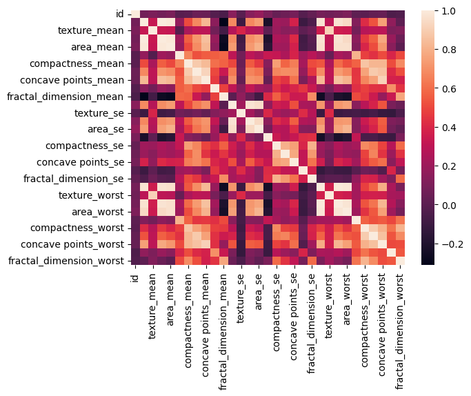

```python
sns.heatmap(df.corr());
```

The heatmap above shows all the columns and therefore looks a little convoluted. We can also see a pattern in the heatmap due to the repeated occurence of similar columns. As there is visually little difference between these re-occuring patterns, we can try to zoom in on just the columns with the **mean** values.

```python
df_mean = df[['diagnosis','radius_mean','texture_mean','perimeter_mean','area_mean','smoothness_mean','compactness_mean','concavity_mean','concave points_mean','symmetry_mean','fractal_dimension_mean']]
```

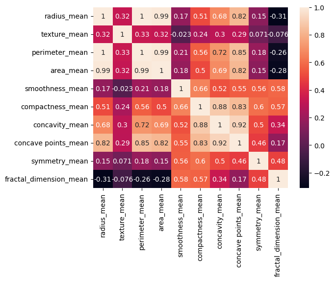

```python
sns.heatmap(df_mean.corr(),annot=True);
```

We can see that some of the values had strong correlations with eachother, such as `area_mean` with `perimeter_mean` and `radius_mean`. However, the perimeter and the radius of a tumour can help in calculating the area, so it can be reasoned that these are simply different way of expressing the same value.

Therefore, we want to look at values that are not closely related with each other. For example, `area_mean` has a strong correlation with `concave points_mean`. Using a scatterplot, we can compare the datapoints with each other and see if we can find a pattern.

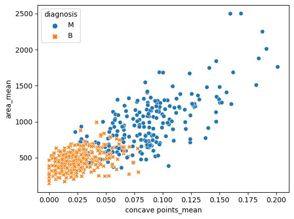

```python
sns.scatterplot(data=df_mean, x="concave points_mean", y="area_mean", hue="diagnosis", style="diagnosis")
```

We can indeed see a strong positive correlation between `area_mean` and `concave points_mean`. If we want to further confirm this observation, we can use Seaborn's `lmplot` to fit a regression model to our data.

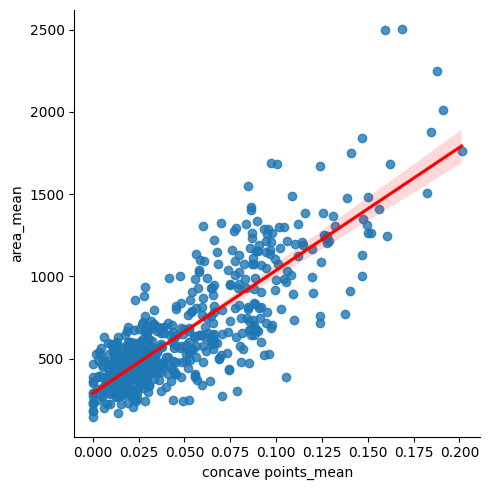

```python
sns.lmplot(data=df_mean, x="concave points_mean", y="area_mean",line_kws={'color': 'red'})
```

Again, the line representing the regression model confirms our previous observations about a strongly positive correlation.

So what about other variables with a degree of correlation to `area_mean`? Can we see a clear pattern with variables such as `concavity_mean`, `compactness_mean`, `smoothness_mean`, or `symmetry_mean` as well?

We can compare these variables with `concave points_mean` by using a pairplot.

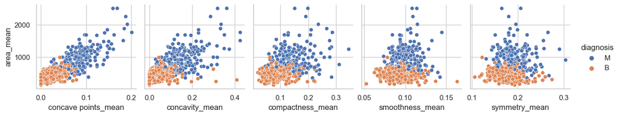

```python
sns.set(style='whitegrid', context='notebook')
sns.pairplot(df_mean, x_vars=['concave points_mean', 'concavity_mean', 'compactness_mean', 'smoothness_mean', 'symmetry_mean'], y_vars=['area_mean'], hue='diagnosis', height=2.5);
plt.show()
```

The pairplot shows us that the other variables do not conform to the hypothetical regression line as much as `concave points_mean` does, and especially `compactness_mean`, `smoothness_mean`, and `symmetry_mean` are quite scattered. `concavity_mean` resembles `concave points_mean` a little, but tends to be on the scattered side as well.

# Data Provisioning

## Data Requirements

To be able to collect the right data, I have to make sure that I understand where I have to retrieve it from. There is no use in collecting data that does not come from a reliable source, as there is a chance that this data is not accurate (anymore).

### Sources

As the domain of breast cancer is almost wholly related to the overarching domain of healthcare, it would be preferable to use data originating from hospitals or medical specialists who have collected data on tumours found in breast cancer. This limits the amount of sources which can be utilised quite substantially, but this is not surprising as the domain itself is also quite limited in scope.

### Stakeholders

Performing research on this topic raises the question of whom would potentially benefit from the usage or storage of this data? We can think of several stakeholders who would have stakes in publishing this data publically:

- **Medical specialists**: Medical specialists who have performed the research and collected the results benefit from publishing their these, as it enables the scientific and medical community to evaluate the findings themselves. It allows other people to repeat or build on these results and confirm the findings themselves.
- **Breast cancer patients**: Breast cancer patients can potentially benefit from storing this data as it allows other researchers to analyse the data and potentially find ways to make the classification of breast cancer tumours easier and faster, resulting in higher chances of survival as the cancer can be treated more rapidly.

### Data Elements

The data that will be used to carry out this research is the *Breast Cancer Dataset* retrieved from **Kaggle**. Kaggle is a subsidiary company of **Google** which allows users to find and publish datasets for use in data science<sup>7</sup>. When we dig deeper, we find that the data originates from diagnosed cases collected by Dr. William H. Wolberg for the University of Wisconsin Hospitals in 1992. The University of Wisconsin Hospitals is an academic hospital in Madison, Wisconsin, United States of America, which can be assumed to be a reliable source of data to be used for serious ML application.

The dataset consists of 32 columns and 569 columns. Columns 3 till 32 are divided between the **mean** of the data, the **standard error** of the data, and the **worst value** of the data. It is provided as a CSV file and contains the following important data:

1. `ID`: The unique identification number of the diagnosed case.
2. `Diagnosis`: The general diagnosis made by a medical professional, classified by 'M' (malignant) and 'B' (benign).
3. `Radius`: The distances from centre to points on the perimeter.
4. `Texture`: The standard deviation of greyscale values.
5. `Perimeter`: The measurements of the tumour perimeter.
6. `Area`: The area measurements of the tumour.
7. `Smoothness`: The local variation in radius lengths.
8. `Compactness`: The tumour's compactness measurements calculated by `perimeter^2 / area - 1.0`.
9. `Concavity`: The severities of concave portions of the contour.
10. `Concave points`: The number of concave portions of the contour.
11. `Symmetry`: The degree of symmetry of the tumour.
12. `Fractal dimension`: The result of `"coastline approximation" - 1`.

## Data Collection

### Collecting information

The topic of this research has been selected based on an already-provided dataset, and the current dataset already contains all of the data that we need for the scope of this project. I have not been able to find any more data that could enhance the dataset I already have, and therefore I feel that there is little need to source more data.

### Storing data

In storing the data used for this research, I set the following criteria in trying to find the right hosting environment:

- **Accessibility.** The data should be able to be accessed at any time and place.
- **Practicality.** Storing and retrieving the data should be as easy as possible.
- **Version control.** The hosting environment should keep notes of the different versions of data.

At first, I used Google Drive due to my familiarity with the platform. However, I realised that Google Drive is not a very transparent service to store data, so I ended up switching to GitHub. While I am less familiar with this platform, I do think that it is more beneficial for my data to be publicly available.

### Extracting data

Due to the limited scope of the project, the data to be used will be extracted from a .csv file. Currently I have no plans to connect the data to the internet by means of an online database or API, as the data that I will use is already publicly available, and I doubt whether I will change much of the data already provided in the dataset. Furthermore, as my data is only meant to showcase the potential of machine learning, there would be little use in retrieving the data for practical purposes.

## Data Understanding

### Exploratory Data Analysis

In order to get a good sense of how machine learning can predict the results based on existing data, it is important to understand this data beforehand. By analysing the data before using it in an algorithm, we can already deduce important information and create hypotheses about what the data tells us.

By using the `describe` function in `Pandas`, Python will automatically calculate the statistics that we can use to describe the data with.

```python
#df_mean['diagnosis'].replace({'B':'Benign','M':'Malignant'}, inplace=True)
```

```python
df_mean.describe()
```

|  | radius_mean | texture_mean | perimeter_mean | area_mean | smoothness_mean | compactness_mean | concavity_mean | concave points_mean | symmetry_mean | fractal_dimension_mean |
| --- | --- | --- | --- | --- | --- | --- | --- | --- | --- | --- |
| count | 569.000000 | 569.000000 | 569.000000 | 569.000000 | 569.000000 | 569.000000 | 569.000000 | 569.000000 | 569.000000 | 569.000000 |
| mean | 14.127292 | 19.289649 | 91.969033 | 654.889104 | 0.096360 | 0.104341 | 0.088799 | 0.048919 | 0.181162 | 0.062798 |
| std | 3.524049 | 4.301036 | 24.298981 | 351.914129 | 0.014064 | 0.052813 | 0.079720 | 0.038803 | 0.027414 | 0.007060 |
| min | 6.981000 | 9.710000 | 43.790000 | 143.500000 | 0.052630 | 0.019380 | 0.000000 | 0.000000 | 0.106000 | 0.049960 |
| 25% | 11.700000 | 16.170000 | 75.170000 | 420.300000 | 0.086370 | 0.064920 | 0.029560 | 0.020310 | 0.161900 | 0.057700 |
| 50% | 13.370000 | 18.840000 | 86.240000 | 551.100000 | 0.095870 | 0.092630 | 0.061540 | 0.033500 | 0.179200 | 0.061540 |
| 75% | 15.780000 | 21.800000 | 104.100000 | 782.700000 | 0.105300 | 0.130400 | 0.130700 | 0.074000 | 0.195700 | 0.066120 |
| max | 28.110000 | 39.280000 | 188.500000 | 2501.000000 | 0.163400 | 0.345400 | 0.426800 | 0.201200 | 0.304000 | 0.097440 |

From the above table, we can see the calculated `count`, `mean`, `standard deviation (std)`, `minimum (min)`, quartile percentiles, and `maximum (max)` from all columns in the dataset.

Some values that stand out are:

- **High std in area_mean.** Standard deviation represents the mean distance of every observation relative to the mean of all observations. A high standard deviation often signifies a high amount of variance in the observations.

Next, we can visualise the distribution of observations by using boxplots, making it easier for us to see how tumours diagnosed as benign and malignant compare to each other. I used the `area_mean` as axis for the distribution, as this probably takes the variations in tumours shapes in account the best.

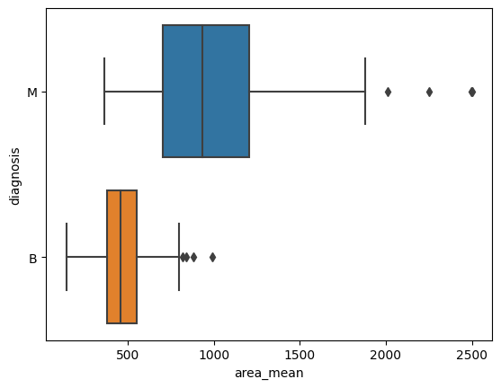

```python
sns.boxplot(data=df_mean, x="area_mean", y="diagnosis")
```

From the above boxplot, we can make several assumptions:

- **The distribution of benign tumours is smaller than those of malignant tumours.** This could signify that most benign tumours tend to be of a similar size range, while malignant tumours are much more varied in size.
- **The interquartile of benign tumours is completely left of the interquartile of malignant tumours.** While the whiskers of the boxplot do overlap, both interquartiles are completely clear of each other, suggesting that benign tumours are generally smaller than malignant ones.

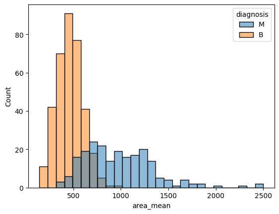

```python
sns.histplot(data=df_mean, x="area_mean", hue="diagnosis")
```

While there is some overlap, the plot shows us similar information compared to the box plot. While there is some overlap, benign tumours tend to be smaller in radius and tend to gravitate towards a more narrow range of sizes, while malignant tumours are mostly larger and more spread out in regards to size.

### Explanatory Data Visualisation

Next, we can do some explanatory data visualisation of our data. This way, we can check the integrity of the data and find patterns which can help us in understanding the data.

One of the tools we can use to make sure that our data is complete and all values are accounted for. While we were able to see that all columns had the same number of rows with the `describe` function, it's nice to visualise this information for confirmation. We can use the `matrix` function from the `missingno` library to easily do this.

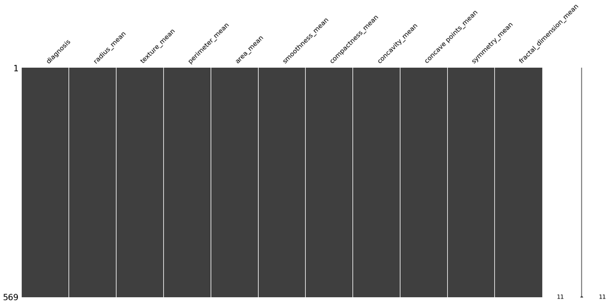

```python
msno.matrix(df_mean)
```

The bars above show that all columns are 100% complete. This means that there is no need to research and fill in the missing data.

Next, we want to see whether the data holds any notable patterns. In our previous heatmap, we were able to see that some of the values had strong correlations with eachother, such as `area_mean` with `perimeter_mean` and `radius_mean`. However, the perimeter and the radius of a tumour can help in calculating the area, so it can be reasoned that these are simply different way of expressing the same value.

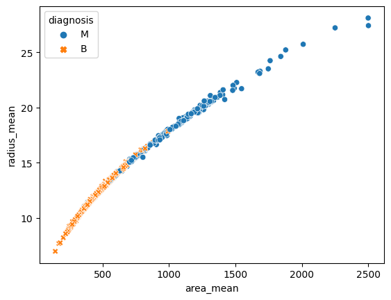

```python
sns.scatterplot(data=df_mean, x="area_mean", y="radius_mean", hue="diagnosis", style="diagnosis")
```

As the correlation between `radius_mean` and `area_mean` is 0.99, we can see that almost all values fit to the same curve in the plot.

However, there are more aspects of a tumour apart from radius, perimeter, and surface area that can help us determine the nature of a tumour. Another recorded attribute of tumours is `concave points_mean`, or simply the amount of irregularities on the surface of a tumour, as tumours are not perfectly smooth spheres. We will plot it against `area_mean` again due to its high correllation. I divided the plot points between the categories in `diagnosis`: Benign and Malignant.

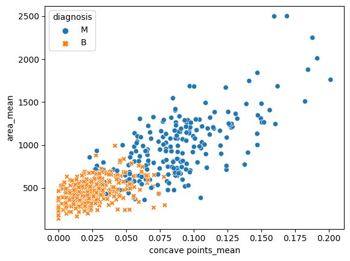

```python
sns.scatterplot(data=df_mean, x="concave points_mean", y="area_mean", hue="diagnosis", style="diagnosis")
```

We can see that the recorded observations of benign and malignant tumours clearly gather into two separate "groups": Benign tumours tend to have a smaller radius and less concave points, while malignant tumours tend to have a larger radius and a higher amount of concave points.

[figure not shown]

```python
sns.lmplot(data=df_mean, x="concave points_mean", y="area_mean", hue="diagnosis", markers =['o', 'x'])
```

## Data Preparation

Based on results from the previous steps, I do not believe that there is much more preparation involved to enhance the usability of the data for our algorithm.

The only change that I would make to the dataset, is by selecting only the **diagnosis** and the **mean** values of the dataset and drop the rest. This was already done earlier for simplicity, by creating a new dataset like shown below.

```python
df_mean = df[['diagnosis','radius_mean','texture_mean','perimeter_mean',
              'area_mean','smoothness_mean','compactness_mean','concavity_mean',
              'concave points_mean','symmetry_mean','fractal_dimension_mean']]
```

[output not shown]

# Predictions

## Preprocessing

Now that we have the data we need to be able to conduct our research, and have determined which variables we wish to use for, it is time to actually make the data usable for input into the machine learning algorithm. In order to achieve this, we will go through the processes of **Feature Selection**, **Splitting train/test**, and **Scaling**.

### Feature Selection

As stated previously, it is important to select the features which we want to use to predict the type of tumour found breast cancer. The first thing to do would be to convert any object-type variables into numerical values, as algorithms can only work with numbers. The only column in the dataset with object-type variables is `diagnosis`.

```python
df_mean.sample(10)
```

|  | diagnosis | radius_mean | texture_mean | perimeter_mean | area_mean | smoothness_mean | compactness_mean | concavity_mean | concave points_mean | symmetry_mean | fractal_dimension_mean |
| --- | --- | --- | --- | --- | --- | --- | --- | --- | --- | --- | --- |
| 239 | M | 17.460 | 39.28 | 113.40 | 920.6 | 0.09812 | 0.12980 | 0.14170 | 0.08811 | 0.1809 | 0.05966 |
| 133 | B | 15.710 | 13.93 | 102.00 | 761.7 | 0.09462 | 0.09462 | 0.07135 | 0.05933 | 0.1816 | 0.05723 |
| 497 | B | 12.470 | 17.31 | 80.45 | 480.1 | 0.08928 | 0.07630 | 0.03609 | 0.02369 | 0.1526 | 0.06046 |
| 155 | B | 12.250 | 17.94 | 78.27 | 460.3 | 0.08654 | 0.06679 | 0.03885 | 0.02331 | 0.1970 | 0.06228 |
| 561 | B | 11.200 | 29.37 | 70.67 | 386.0 | 0.07449 | 0.03558 | 0.00000 | 0.00000 | 0.1060 | 0.05502 |
| 280 | M | 19.160 | 26.60 | 126.20 | 1138.0 | 0.10200 | 0.14530 | 0.19210 | 0.09664 | 0.1902 | 0.06220 |
| 198 | M | 19.180 | 22.49 | 127.50 | 1148.0 | 0.08523 | 0.14280 | 0.11140 | 0.06772 | 0.1767 | 0.05529 |
| 51 | B | 13.640 | 16.34 | 87.21 | 571.8 | 0.07685 | 0.06059 | 0.01857 | 0.01723 | 0.1353 | 0.05953 |
| 495 | B | 14.870 | 20.21 | 96.12 | 680.9 | 0.09587 | 0.08345 | 0.06824 | 0.04951 | 0.1487 | 0.05748 |
| 273 | B | 9.742 | 15.67 | 61.50 | 289.9 | 0.09037 | 0.04689 | 0.01103 | 0.01407 | 0.2081 | 0.06312 |

Instead of having a single identifying letter, we want to use an identifying number. Therefore, we create a new column and map the values in `diagnosis` as numericals: **1** for Benign tumours, and **2** for Malignant tumours.

```python
df_mean["diagnosis_ID"] = df["diagnosis"].map({"B": 1, "M": 2})
df_mean.sample(10)
```

|  | diagnosis | radius_mean | texture_mean | perimeter_mean | area_mean | smoothness_mean | compactness_mean | concavity_mean | concave points_mean | symmetry_mean | fractal_dimension_mean | diagnosis_ID |
| --- | --- | --- | --- | --- | --- | --- | --- | --- | --- | --- | --- | --- |
| 472 | B | 14.920 | 14.93 | 96.45 | 686.9 | 0.08098 | 0.08549 | 0.05539 | 0.03221 | 0.1687 | 0.05669 | 1 |
| 435 | M | 13.980 | 19.62 | 91.12 | 599.5 | 0.10600 | 0.11330 | 0.11260 | 0.06463 | 0.1669 | 0.06544 | 2 |
| 264 | M | 17.190 | 22.07 | 111.60 | 928.3 | 0.09726 | 0.08995 | 0.09061 | 0.06527 | 0.1867 | 0.05580 | 2 |
| 432 | M | 20.180 | 19.54 | 133.80 | 1250.0 | 0.11330 | 0.14890 | 0.21330 | 0.12590 | 0.1724 | 0.06053 | 2 |
| 538 | B | 7.729 | 25.49 | 47.98 | 178.8 | 0.08098 | 0.04878 | 0.00000 | 0.00000 | 0.1870 | 0.07285 | 1 |
| 98 | B | 11.600 | 12.84 | 74.34 | 412.6 | 0.08983 | 0.07525 | 0.04196 | 0.03350 | 0.1620 | 0.06582 | 1 |
| 406 | B | 16.140 | 14.86 | 104.30 | 800.0 | 0.09495 | 0.08501 | 0.05500 | 0.04528 | 0.1735 | 0.05875 | 1 |
| 205 | M | 15.120 | 16.68 | 98.78 | 716.6 | 0.08876 | 0.09588 | 0.07550 | 0.04079 | 0.1594 | 0.05986 | 2 |
| 41 | M | 10.950 | 21.35 | 71.90 | 371.1 | 0.12270 | 0.12180 | 0.10440 | 0.05669 | 0.1895 | 0.06870 | 2 |
| 12 | M | 19.170 | 24.80 | 132.40 | 1123.0 | 0.09740 | 0.24580 | 0.20650 | 0.11180 | 0.2397 | 0.07800 | 2 |

Next, we want to determine which variables we actually want to use to train the model. Preferably we want to use variables that has distinguishable values per class (diagnosis), as they are less likely to add "noise" to our model.

An easy way to do this is by using boxplots to visualise the distribution of the values per class. As some variables in our data uses different numerical scales, we will create 3 separate boxplots. I tried combining these as subplots, but I was unable to get the layout right, and therefore decided to run these as 3 separate queries.

```
array([<AxesSubplot:title={'center':'smoothness_mean'}, xlabel='diagnosis'>,
       <AxesSubplot:title={'center':'compactness_mean'}, xlabel='diagnosis'>,
       <AxesSubplot:title={'center':'concavity_mean'}, xlabel='diagnosis'>,
       <AxesSubplot:title={'center':'concave points_mean'}, xlabel='diagnosis'>,
       <AxesSubplot:title={'center':'symmetry_mean'}, xlabel='diagnosis'>,
       <AxesSubplot:title={'center':'fractal_dimension_mean'}, xlabel='diagnosis'>],
      dtype=object)
```

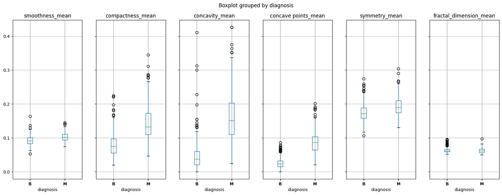

```python
df_mean.boxplot(column=['smoothness_mean','compactness_mean','concavity_mean','concave points_mean','symmetry_mean','fractal_dimension_mean'], by="diagnosis", figsize=(20,7), layout=(1,6))
```

```
array([<AxesSubplot:title={'center':'radius_mean'}, xlabel='diagnosis'>,
       <AxesSubplot:title={'center':'texture_mean'}, xlabel='diagnosis'>,
       <AxesSubplot:title={'center':'perimeter_mean'}, xlabel='diagnosis'>],
      dtype=object)
```

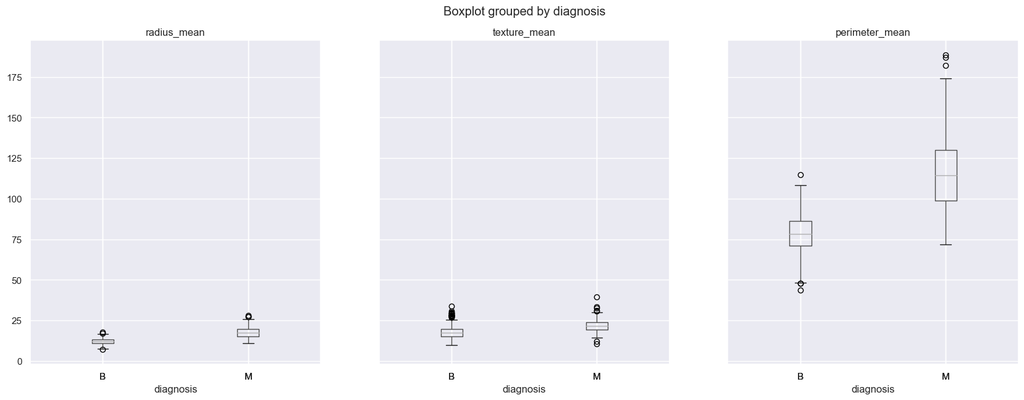

```python
df_mean.boxplot(column=['radius_mean','texture_mean','perimeter_mean'], by="diagnosis", figsize=(20,7), layout=(1,3))
```

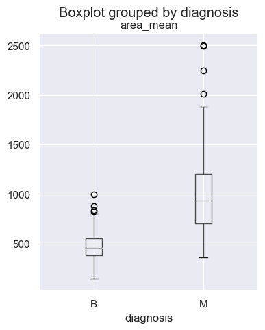

```python
df_mean.boxplot(column=['area_mean'], by="diagnosis", figsize=(4,5), layout=(1,1))
```

When looking for suitable variables, we want to look for variables that have the least amount of overlap between classes. In other words, plots which are the farthest away from eachother vertically.

Several variables do not have overlapping interquartile ranges (the spread of values between 25% and 75% of all values), such as `compactness_mean`, `concavity_mean`, `concave points_mean`, `perimeter_mean`, and `area_mean`.

We can use these variables to train the model and see what sort of accuracy we will be seeing. If the accuracy is short of our target variable, we can try and tweak some of the variables to see what works best.

```python
X = df_mean[["area_mean", "concave points_mean", "compactness_mean", "concavity_mean", "perimeter_mean"]]
#X = df_mean[["area_mean", "concave points_mean"]]
#X = df_mean[["area_mean", "concavity_mean"]]
#X = df_mean[["compactness_mean", "concavity_mean"]]
y = df_mean["diagnosis_ID"]
```

Trying out several sets of variables, both the 1st and the 3rd set gave me similar results. Therefore, I decided to go ahead with the 1st set, as it covered more datapoints to make predictions off of, and I therefore assumed that this could give more more accurate predictions with larger sets of data.

### Splitting train/test

```python
from sklearn.model_selection import train_test_split
X_train, X_test, y_train, y_test = train_test_split(X, y, test_size=0.21, random_state=42)
print("There are in total", len(X), "observations.")
print("The train set now has", len(X_train), "observations.")
print("The test set now has", len(X_test), "observations.")
```

```
There are in total 569 observations.
The train set now has 449 observations.
The test set now has 120 observations.
```

In order to have a reproducible result for every time the code runs again, I went ahead and chose seed *42* for a consistent test/train set.

With seed 42, a test size of 21% gave me the most accurate predictions (94,16% accuracy) that came closest to my target variable of 95%.

### Scaling

For this research, we are using the *K-Nearest Neighbour* algorithm to predict the class per observation, based on the given variables. In KNN, the prediction is made by estimating the likelyhood that a data point belongs to one class or the other based on the class of the nearest datapoints.<sup>8</sup>

The distance to the nearest datapoints is calculated using Euclidian distance, which is the absolute distance between two values. In order to ensure that the same unit of measurement is used among features, and that no features weigh more than others, we want to transform the values into the same unit of measurement, which will be Standard Deviation (SD) for this project.

Below, we use a scaler called `StandardScaler` in order to transform the values, after which we can visualise the results in a scatterplot.

[figure not shown]

```python
from sklearn.preprocessing import StandardScaler
scaler = StandardScaler()
scaler.fit(X_train)
X_train = scaler.transform(X_train)
X_test = scaler.transform(X_test)

sns.set(rc={"figure.figsize":(10, 6)})
ax = sns.scatterplot(x=X_train[:,0], y=X_train[:,1], hue=y_train, palette="viridis")
ax.set(xlabel=X.columns[0], ylabel=X.columns[1], title="Distance between diagnoses (σ)")
ax.legend(ax.legend_.legendHandles, df_mean["diagnosis_ID"].unique(), title="Diagnosis")
```

## Modelling

In the first step, we will actually load the K-Nearest Neighbours classifier algorithm and load in our dataset with the selected variables.

The second step will show us the accuracy of the predictions that the model made using our test/train set, by comparing the results of the predictions with the actual results in the individual observations.

```python
from sklearn.neighbors import KNeighborsClassifier
model = KNeighborsClassifier()
model.fit(X_train, y_train)
pred = model.predict(X_test)

from sklearn.metrics import accuracy_score
acc = accuracy_score(pred, y_test)
print("Accuracy:", acc)
```

```
Accuracy: 0.9416666666666667
```

As I said earlier, with our current variables and test/train parameters, the model gives us an accuracy of 94,16%, coming very close to our desired target variable of 95%.

## Evaluation

Now, we can evaluate the results from our model regarding accuracy. We will split the results by class so get an insight into whether the accuracy differs per class.

```python
from sklearn.metrics import classification_report
report = classification_report(y_test, pred, target_names=df_mean["diagnosis"].unique())
print(report)
```

[output not shown]

We can see that there are small differences between the results of both classes.

Looking at the precision of predictions, out of the total amount of tumours predicted per class, 94% actually identified as Malignant tumours, while 93% actually identified as Benign tumours.

Looking further at the recall values, we can see that of these predictions, 96% of the Malignant tumours were correctly predicted, while 91% of Benign tumours were correctly predicted.

Lastly, the F1-score tells us how suitable the models are for predicting the tumour classes. The closer these values are to **1**, the better the model fits. For Malignant tumours this is a score of 0.95, and for Benign tumours 0.92.

One reason for the difference in results between these classes could be visualised using the scaler.

[figure not shown]

```python
sns.set(rc={"figure.figsize":(10, 6)})
ax = sns.scatterplot(x=X_train[:,0], y=X_train[:,1], hue=y_train, palette="viridis")
ax.set(xlabel=X.columns[0], ylabel=X.columns[1], title="Distance between diagnoses (σ)")
ax.legend(ax.legend_.legendHandles, df_mean["diagnosis_ID"].unique(), title="Diagnosis")
```

## 4. Conclusion

As seen in the modelling and evaluation above, the average accuracy of our model in predicting the type of tumour is **94,16%**. While this falls just short of the target variable of 95% accuracy which I set for this project, it is still quite close to the mark and I think that it would be a viable way of determining tumour types with a high degree of accuracy.

# Delivery

## Demonstration

In order to finalise the challenge, I was planning to show the results of my research to Drs Aaldering and have her views on how this research could impact the medical field of breast cancer. In particular, I wanted to show her my workflow and explain to her how I was able to reach the results of my project, and what these variables mean to people who do not have any experience in Machine Learning.

While I was hoping to demonstrate my research to her in a face-to-face meeting, Drs Aaldering still kept a very busy schedule, and therefore we had to resort to holding a Teams call. While this was not the most ideal medium to be able to fully explain my work, I felt that it was worth showing this to the person I originally interviewed for my domain understanding.

Unfortunately, disaster struck and the recording of my Teams meeting with her was not saved properly, therefore losing the ability to rewatch the demonstration and write an accurate summary. The summary will therefore consist of the big pointers that came up during the demonstration.

## Feedback

- Drs Aaldering was very glad to meet with me again to discuss the progress that my research had made in the time between the interview and the demonstration. We had a small chat about how "official" this research was, and whether she would have to pay attention to anything in particular. I told her that I would particularly like her to comment on what would make the research clearer for her to understand.
- I went through each chapter of the notebook with her, and talked her through the steps of how I came by the results of my research. I noticed that it was fairly straightforward for her to understand the project proposal and the data requirements, however she seemed to have some difficulty in understanding some of the graphs shown in data understanding, and later also the part of modelling the data. Personally, I feel that I went over these parts a little too quickly because I felt like I was actually taking too long (as Drs Aaldering still had a busy schedule, and I didn't want to take up too much of her time), and therefore I wasn't completely satisfied with how I tried to convey the technical part of my project.
- When we arrived at the results of the research, she was quite impressed with the high degree of accuracy of my model. She reiterated from the domain understanding interview that the number for current methods of determining breast cancer types lies around 80 - 85% accuracy, and therefore thinks that the increase in accuracy definitely would help with starting up the appropriate treatments sooner.
- She also reiterated from the previous interview that an algorithm with such a high degree of accuracy could be a very helpful tool for medical professionals to speed up cancer type diagnoses, but should never be the sole deciding factor in recommending treatment. She argued that medical professionals should always have the final decision in the kind of treatment, as they as human beings can rationalise with the patient and also recommend alternative ways of treating the cancer which might be more suitable.
- After walking her through the research, she made several remarks regarding improvements. First, she felt that I could perhaps increase the accuracy of my model by using more data to train the model with. Second, she would have liked the layout to be a little more clear, as she found it hard to follow the text combined with the lines of code, and perhaps I could have supported my descriptions with more images. Finally, she said that she would have liked a more detailed explanation of the EDA and later modelling of the data.

## Impact Assessment

In order to analyse what sort of an impact the trained model would have on the domain that it is related to, it is important to assess the capabilities and shortcomings of the model. This way, I can try to minimise the possible misuse of the model, either purposely or by accident. Especially since this model could be employed in a sector where human lives are on the line, I feel that it is important to chart who could benefit from the model, and how potent the model is.

I performed this assessment in cooperation with Drs Aaldering.

### Impact on Society

- **What is exactly the problem? Is it really a problem? Are you sure?**

  > The problem is that with current technologies, the accuracy of determining the type of breast cancer is at around 85%. While this is a high percentage already, we feel that there is always room for improvement, as an improvement in accuracy means that more people can be treated for breast cancer sooner.
- **Are you sure that this technology is solving the RIGHT problem?**

  > We feel that this technology does not necessarily solve the problem, but it can be used as a tool by medical professionals to solve the problem of determining the type of breast cancer.
- **How is this technology going to solve the problem?**

  > This technology will help medical professionals solve the problem by making an accurate prediction of the type of breast cancer tumour and enabling treatment for people with breast cancer to start earlier.
- **What negative effects do you expect from this technology?**

  > We don't think that there will be many negative effects from this technology, as it would be mainly used as a tool to support medical professionals. There is a possibility that the accuracy might decrease if the data is used in real-time and collects more outlying observations, but other than that we don't think that the technology will have negative effects as it is only used in a controlled environment.
- **In what way is this technology contributing to a world you want to live in?**

  > The technology will enable medical professionals to make more accurate assumptions about cancer diagnoses, enabling breast cancer patients to receive the correct kind of treatment earlier. Late or incorrect treatment of breast cancer can result in insufficient or drastic treatment, which can be detrimental to the patients' health and wellbeing. I hope that this technology can help bridge the gap of the remaining 15% of inaccurate diagnoses using current diagnosing techniques, hopefully resulting in more lives being saved.

### Privacy

- **Does the technology register personal data? If yes, what personal data?**

  > The technology does not register any personal data. The only data that is registered are the measurements taken from the breast cancer tumours, which are anonymous and not linked to any names or identifying markers.
- **Do you think the technology invades the privacy of the stakeholders? If yes, in what way?**

  > No, we don't think that this technology invades the privacy of stakeholders, as is does not record or register any information which can be used to infer their identity or disciminate against them.
- **Is the technology is compliant with prevailing privacy and data protection law? Can you indicate why?**

  > We are not aware whether the technology is compliant with any data protection laws, however as the technology does not register any personal data, we believe that there will we little in the way of breaching data protection laws.
- **In which way can you imagine a future impact of the collection of personal data?**

  > We do not believe that the technology contains any data which will affect the stakeholders in any long-term ways.

### Human values

- **How is the identity of the (intended) users affected by the technology?**

  > The technology will be used as a tool by medical professionals to make a more accurate assumption about the type of breast cancer found in the tumour measurements from a patients. For a patient, this means that appropriate treatment can start sooner, increasing their survival rate and possibly mitigating insufficient or drastic treatment which could cause lasting damage.
- **How does the technology influence the users' autonomy?**

  > The technology will only be a tool for medical professionals to help determine the type of breast cancer in patients diagnosed with breast cancer. It will not have the final say about the appropriate treatment, which is still relegated to the medical professional. The patient is free to refuse or accept the suggested treatment or alternatives.
- **What is the effect of the technology on the health and/or well-being of users?**

  > We hope that the technology can be used to more accurately predict the type of breast cancer found in patients based on measurements of the tumour, therefore starting treatment earlier and increasing the rate of survival for the patient.

# References

1. *Cancer*. (n.d.). Stanford Health Care. Retrieved October 6, 2022, from https://stanfordhealthcare.org/medical-conditions/cancer/cancer.html
2. WCRF International. (2022b, April 14). *Worldwide cancer data*. Retrieved October 6, 2022, from https://www.wcrf.org/cancer-trends/worldwide-cancer-data/
3. *Breast cancer*. (2021, March 26). World Health Organisation. Retrieved October 6, 2022, from https://www.who.int/news-room/fact-sheets/detail/breast-cancer
4. Cancer Research UK. (2022, July 6). *Cancer mortality for common cancers*. Retrieved October 6, 2022, from https://www.cancerresearchuk.org/health-professional/cancer-statistics/mortality/common-cancers-compared
5. *UCI Machine Learning Repository: Breast Cancer Wisconsin (Diagnostic) Data Set*. (n.d.). Retrieved October 6, 2022, from http://archive.ics.uci.edu/ml/datasets/breast+cancer+wisconsin+%28diagnostic%29
6. *Biopsy*. (2022, June 2). Cancer.Net. Retrieved October 8, 2022, from https://www.cancer.net/navigating-cancer-care/diagnosing-cancer/tests-and-procedures/biopsy
7. Wikipedia contributors. (2022, October 28). *Kaggle*. Wikipedia. https://en.wikipedia.org/wiki/Kaggle
8. Joby, A. (n.d.). *What Is K-Nearest Neighbor? An ML Algorithm to Classify Data*. https://learn.g2.com/k-nearest-neighbor